# DSP evaluation pairs MIscore

Pablo Porras

14/02/2019

## Evaluation of checked and curated publications of the DSP

I manually download all DSP evaluated PMIDs and also those already curated and avaliable on the IntAct website.

##### Libraries

```r
library(data.table)
library(splitstackshape)
library(stringr)
library(ggplot2)
library(scales)
library(dplyr)
library(ggsignif)
library(UniProt.ws)
library(readxl)
```

#### Data upload

```r
# These come from the Google spreadsheet, manually downloaded.
eval_dsp <- fread("./source_data/20190214_dsp_priority_rev_pred.tsv",
                  header = T,
                  colClasses = "character",
                  stringsAsFactors = F,
                  check.names = T,
                  sep = "\t")

if (!file.exists("./source_data/intact.zip")){
        download.file(url="ftp://ftp.ebi.ac.uk/pub/databases/intact/current/psimitab/intact.zip",destfile = "./source_data/intact.zip",method = "curl")
}

if (!file.exists("./source_data/intact-micluster.zip")){
        download.file(url="ftp://ftp.ebi.ac.uk/pub/databases/intact/current/psimitab/intact-micluster.zip",destfile = "./source_data/intact-micluster.zip",method = "curl")
}


setwd("./source_data")
system("unzip -j intact.zip")
intact <- unique(fread(
  "intact.txt",
  header=T,
  sep="\t",
  colClasses="character",
  check.names = T,
  stringsAsFactors = F))
system("rm intact.txt")
system("rm intact_negative.txt")

system("unzip -j intact-micluster.zip")
intact_micluster <- unique(fread(
  "intact-micluster.txt",
  header=T,
  sep="\t",
  colClasses="character",
  check.names = T,
  stringsAsFactors = F))
system("rm intact-micluster.txt")
system("rm intact-micluster_negative.txt")
setwd("../")
```

### Extract comparison sets

```r
eval_dsp_pmids <- unique(eval_dsp[grepl("yes|Yes",curatable),.(pmid)])

# eval_dsp_pmids_evaluated <- unique(eval_dsp[curatable!="",.(pmid,curatable)])
# fwrite(
#   eval_dsp_pmids,
#   "./source_data/pmids.txt",
#   col.names = F,
#   row.names = F,
#   sep = "\t",
#   quote = F
# )

eval_dsp_pairs <- unique(eval_dsp[grepl("yes|Yes",curatable),.(
  prot_pairs,
  pmid,
  DS.interest.up,
  DS.part_interest.up,
  DS.score.pred)])

eval_dsp_pairs_long <- unique(cSplit(
  eval_dsp_pairs,
  splitCols = "prot_pairs",
  sep = "|",
  direction = "long",
  drop = F
))

eval_dsp_pairs_formatted <- eval_dsp_pairs_long[,.(
  pmids = paste(unique(pmid),collapse = "|"),
  p1 = gsub("_.*", "",prot_pairs),
  p2 = gsub(".*_", "",prot_pairs),
  DS.interest.up,
  DS.part_interest.up,
  DS.score.pred
), by = "prot_pairs"]

intact_human <- intact[grepl('taxid:9606',Taxid.interactor.A) &
                         grepl('taxid:9606',Taxid.interactor.B) &
                         grepl('uniprotkb:',X.ID.s..interactor.A) &
                         grepl('uniprotkb:',ID.s..interactor.B),]
intact_human <- intact_human[,pmid:=gsub("\\|.*","",gsub(".*pubmed:","",Publication.Identifier.s.))]
intact_human <- intact_human[,p1:=gsub("-.*","",gsub("uniprotkb:","",X.ID.s..interactor.A))]
intact_human <- intact_human[,p2:=gsub("-.*","",gsub("uniprotkb:","",ID.s..interactor.B))]
intact_human <- intact_human[,pair_id := apply(data.table(p1,p2,stringsAsFactors = F),
                  1,
                  function(a) { z = sort(a)
                  paste0(z[1],"_",z[2]) })]

intact_human <- data.table(mutate(intact_human,
                                  X.ID.s..interactor.A = paste("uniprotkb:",p1,sep=""),
                                  ID.s..interactor.B = paste("uniprotkb:",p2,sep="")))

publs_curated_dsp <- intact_human[pmid %in% eval_dsp_pmids$pmid]

intact_dsp <- intact_human[(pmid %in% eval_dsp_pmids$pmid)]
dsp_pairs_in_intact <- unique(intact_dsp[,.(
  p1,
  p2,
  pair_id = apply(data.table(p1,p2,stringsAsFactors = F),
                  1,
                  function(a) { z = sort(a)
                  paste0(z[1],"_",z[2]) })
)])

intact_pairs_dsp <- intact_human[(p1 %in% dsp_pairs_in_intact$p1 & p2 %in% dsp_pairs_in_intact$p2) | (p1 %in% dsp_pairs_in_intact$p2 & p2 %in% dsp_pairs_in_intact$p1)]

intact_pairs_dsp_no_dsppmids <- intact_pairs_dsp[!(pmid %in% eval_dsp_pmids$pmid)]

intact_pairs_dsp_mitab <- intact_pairs_dsp[ ,`:=`(pmid = NULL, p1 = NULL, p2 = NULL, pair_id = NULL)]
fwrite(
  intact_pairs_dsp_mitab,
  "./processed_data/intact_pairs_dsp_mitab.txt",
  col.names = T,
  row.names = F,
  quote = F,
  sep = "\t"
)

intact_pairs_dsp_no_dsppmids_mitab <- intact_pairs_dsp_no_dsppmids[ ,`:=`(pmid = NULL, p1 = NULL, p2 = NULL, pair_id = NULL)]
fwrite(
  intact_pairs_dsp_no_dsppmids_mitab,
  "./processed_data/intact_pairs_dsp_no_dsppmids_mitab.txt",
  col.names = T,
  row.names = F,
  quote = F,
  sep = "\t"
)
```

#### Obtain non-DSP publication sets for comparison

I need to have a set publications unrelated with the DSP, for which I run the same comparison as I do for the DSP publications. I select these among low-through put publications, checking what is the maximum amount of expanded interactions that DSP publications have. I decide to produce two sets, one that covered the time frame during which the DSP has been active and another predating it. The reason for this is that Margaret was specifically targeting proteins with no UniProt CC lines during the time of the DSP, so it could appear as if the ‘control’ set is actually better than the DSP at finding novel interacting pairs.

##### CC lines subset

```r
# Count expanded interactions
publ_count_exp_int <- unique(intact_human[,.(
  nr_exp_ints = .N,
  Creation.date = as.Date(Creation.date, "%Y/%m/%d"),
  Source.database.s.
),
by = "pmid"])

# Map to DSP publications
eval_dsp_pmids_count <- unique(merge(
  eval_dsp_pmids,
  publ_count_exp_int,
  by = "pmid",
  all.x = T,
  all.y = F
))

# Max number of expanded binaries per DSP publication
max(eval_dsp_pmids_count[!is.na(nr_exp_ints)]$nr_exp_ints)
```

```
## [1] 81
```

```r
# Select low-throughput publications only from intact_human
lt_publs <- publ_count_exp_int[nr_exp_ints < 100]

# Select the subset of publications, roughly within the same period as DSP, which do not include DSP pairs and excluding DIP records, since they come from mass import and the creation date is not indicative of when they were curated.
lt_publs_no_dsp_year <- lt_publs[Creation.date >= min(eval_dsp_pmids_count[!is.na(nr_exp_ints)]$Creation.date) &
                                   Creation.date <= max(eval_dsp_pmids_count[!is.na(nr_exp_ints)]$Creation.date) &
                                   !(pmid %in% eval_dsp_pmids$pmid) &
                                   Source.database.s. != 'psi-mi:"MI:0465"(DIP)']

# Select protein pairs from these publications
no_dsp_pairs <- unique(intact_human[pmid %in% lt_publs_no_dsp_year$pmid &
                                      !is.na(p1) &
                                      !is.na(p2),.(
  p1,
  p2,
  pair_id = apply(data.table(p1,p2,stringsAsFactors = F),
                  1,
                  function(a) { z = sort(a)
                  paste0(z[1],"_",z[2]) })
)])

# Produce adequate MITAB files for non DSP publications selected. REMEMBER TO PUT A HASH ON THE COLUMN TITLES!!!
intact_pairs_nodsp <- intact_human[((p1 %in% no_dsp_pairs$p1 & p2 %in% no_dsp_pairs$p2) | (p1 %in% no_dsp_pairs$p2 & p2 %in% no_dsp_pairs$p1)) & Source.database.s. != 'psi-mi:"MI:0465"(DIP)']
intact_pairs_nodsp_no_dsppmids <- intact_pairs_nodsp[!(pmid %in% lt_publs_no_dsp_year$pmid)]

intact_pairs_nodsp_mitab <- intact_pairs_nodsp[ ,`:=`(pmid = NULL, p1 = NULL, p2 = NULL, pair_id = NULL)]
fwrite(
  intact_pairs_nodsp_mitab,
  "./processed_data/intact_pairs_nodsp_mitab.txt",
  col.names = T,
  row.names = F,
  quote = F,
  sep = "\t"
)

intact_pairs_nodsp_no_dsppmids_mitab <- intact_pairs_nodsp_no_dsppmids[ ,`:=`(pmid = NULL, p1 = NULL, p2 = NULL, pair_id = NULL)]
fwrite(
  intact_pairs_nodsp_no_dsppmids_mitab,
  "./processed_data/intact_pairs_nodsp_no_dsppmids_mitab.txt",
  col.names = T,
  row.names = F,
  quote = F,
  sep = "\t"
)
```

##### Old random subset

```r
# Select the subset of publications, well before DSP, which do not include DSP pairs and excluding MINT records, since they come from mass import and the creation date is not indicative of when they were curated.
lt_publs_no_dsp_old_year <- lt_publs[Creation.date >= "2014-06-01" &
                                   Creation.date <= "2016-01-21" &
                                   !(pmid %in% eval_dsp_pmids$pmid) &
                                   grepl("MINT",Source.database.s.)]

# Select protein pairs from these publications
no_dsp_old_pairs <- unique(intact_human[pmid %in% lt_publs_no_dsp_old_year$pmid &
                                      !is.na(p1) &
                                      !is.na(p2),.(
  p1,
  p2,
  pair_id = apply(data.table(p1,p2,stringsAsFactors = F),
                  1,
                  function(a) { z = sort(a)
                  paste0(z[1],"_",z[2]) })
)])

# Produce adequate MITAB files for non DSP publications selected. REMEMBER TO PUT A HASH ON THE COLUMN TITLES!!!
intact_pairs_nodsp_old <- intact_human[((p1 %in% no_dsp_old_pairs$p1 & p2 %in% no_dsp_old_pairs$p2) | (p1 %in% no_dsp_old_pairs$p2 & p2 %in% no_dsp_old_pairs$p1)) &  grepl("MINT",Source.database.s.)]
intact_pairs_nodsp_old_no_dsppmids <- intact_pairs_nodsp_old[!(pmid %in% lt_publs_no_dsp_old_year$pmid)]

intact_pairs_nodsp_old_mitab <- intact_pairs_nodsp_old[ ,`:=`(pmid = NULL, p1 = NULL, p2 = NULL, pair_id = NULL)]
fwrite(
  intact_pairs_nodsp_old_mitab,
  "./processed_data/intact_pairs_nodsp_old_mitab.txt",
  col.names = T,
  row.names = F,
  quote = F,
  sep = "\t"
)

intact_pairs_nodsp_old_no_dsppmids_mitab <- intact_pairs_nodsp_old_no_dsppmids[ ,`:=`(pmid = NULL, p1 = NULL, p2 = NULL, pair_id = NULL)]
fwrite(
  intact_pairs_nodsp_old_no_dsppmids_mitab,
  "./processed_data/intact_pairs_nodsp_old_no_dsppmids_mitab.txt",
  col.names = T,
  row.names = F,
  quote = F,
  sep = "\t"
)
```

### Uploading MIscore before/after

I get the MIscore values applying the algorithm on the local files produced in the previous step. REMEMBER TO PUT A HASH ON THE COLUMN TITLES!!!

```r
intact_pairs_dsp_mitab_miscore <- fread(
  "./processed_data/intact_pairs_dsp_clustered.txt",
  header = F,
  check.names = T,
  stringsAsFactors = F,
  colClasses = "character"
)
colnames(intact_pairs_dsp_mitab_miscore) <- colnames(intact_pairs_dsp_no_dsppmids_mitab)[1:15]

intact_pairs_dsp_no_dsppmids_mitab_miscore <- fread(
  "./processed_data/intact_pairs_dsp_no_dsppmids_clustered.txt",
  header = F,
  check.names = T,
  stringsAsFactors = F,
  colClasses = "character"
)
colnames(intact_pairs_dsp_no_dsppmids_mitab_miscore) <- colnames(intact_pairs_dsp_no_dsppmids_mitab)[1:15]

intact_pairs_nodsp_mitab_miscore <- fread(
  "./processed_data/intact_pairs_nodsp_clustered.txt",
  header = F,
  check.names = T,
  stringsAsFactors = F,
  colClasses = "character"
)
colnames(intact_pairs_nodsp_mitab_miscore) <- colnames(intact_pairs_dsp_no_dsppmids_mitab)[1:15]

intact_pairs_nodsp_no_dsppmids_mitab_miscore <- fread(
  "./processed_data/intact_pairs_nodsp_no_dsppmids_clustered.txt",
  header = F,
  check.names = T,
  stringsAsFactors = F,
  colClasses = "character"
)
colnames(intact_pairs_nodsp_no_dsppmids_mitab_miscore) <- colnames(intact_pairs_dsp_no_dsppmids_mitab)[1:15]

intact_pairs_nodsp_old_mitab_miscore <- fread(
  "./processed_data/intact_pairs_nodsp_old_clustered.txt",
  header = F,
  check.names = T,
  stringsAsFactors = F,
  colClasses = "character"
)
colnames(intact_pairs_nodsp_old_mitab_miscore) <- colnames(intact_pairs_dsp_no_dsppmids_mitab)[1:15]

intact_pairs_nodsp_old_no_dsppmids_mitab_miscore <- fread(
  "./processed_data/intact_pairs_nodsp_old_no_dsppmids_clustered.txt",
  header = F,
  check.names = T,
  stringsAsFactors = F,
  colClasses = "character"
)
colnames(intact_pairs_nodsp_old_no_dsppmids_mitab_miscore) <- colnames(intact_pairs_dsp_no_dsppmids_mitab)[1:15]
```

### Comparison before/after dsp

##### Preformat the data: DSP

```r
intact_pairs_dsp_after <- unique(intact_pairs_dsp_mitab_miscore[,.(
  pair_id = apply(data.table(gsub("uniprotkb:","",X.ID.s..interactor.A),
                             gsub("uniprotkb:","",ID.s..interactor.B),
                             stringsAsFactors = F),
                  1,
                  function(a) { z = sort(a)
                  paste0(z[1],"_",z[2]) }),
  miscore_after = as.numeric(gsub(".*miscore:","",Confidence.value.s.)))])

intact_pairs_dsp_before <- unique(intact_pairs_dsp_no_dsppmids_mitab_miscore[,.(
  # p1 = gsub("-.*","",gsub("uniprotkb:","",X.ID.s..interactor.A)),
  # p2 = gsub("-.*","",gsub("uniprotkb:","",ID.s..interactor.B)),
  pair_id = apply(data.table(gsub("uniprotkb:","",X.ID.s..interactor.A),
                             gsub("uniprotkb:","",ID.s..interactor.B),
                             stringsAsFactors = F),
                  1,
                  function(a) { z = sort(a)
                  paste0(z[1],"_",z[2]) }),
  miscore_before = as.numeric(gsub(".*miscore:","",Confidence.value.s.)))])

comp_pairs_dsp_miscore <- unique(merge(
  intact_pairs_dsp_before,
  intact_pairs_dsp_after,
  by = "pair_id",
  all = T
  ))

comp_pairs_dsp_miscore[is.na(miscore_before)]$miscore_before <- 0
comp_pairs_dsp_miscore[,diff:=(miscore_after-miscore_before)]
comp_pairs_dsp_miscore[,set:="dsp"]
```

##### Preformat the data: non-DSP cc-lines

```r
intact_pairs_nodsp_after <- unique(intact_pairs_nodsp_mitab_miscore[,.(
  # p1 = gsub("-.*","",gsub("uniprotkb:","",X.ID.s..interactor.A)),
  # p2 = gsub("-.*","",gsub("uniprotkb:","",ID.s..interactor.B)),
  pair_id = apply(data.table(gsub("uniprotkb:","",X.ID.s..interactor.A),
                             gsub("uniprotkb:","",ID.s..interactor.B),
                             stringsAsFactors = F),
                  1,
                  function(a) { z = sort(a)
                  paste0(z[1],"_",z[2]) }),
  miscore_after = as.numeric(gsub(".*miscore:","",Confidence.value.s.)))])

intact_pairs_nodsp_before <- unique(intact_pairs_nodsp_no_dsppmids_mitab_miscore[,.(
  # p1 = gsub("-.*","",gsub("uniprotkb:","",X.ID.s..interactor.A)),
  # p2 = gsub("-.*","",gsub("uniprotkb:","",ID.s..interactor.B)),
  pair_id = apply(data.table(gsub("uniprotkb:","",X.ID.s..interactor.A),
                             gsub("uniprotkb:","",ID.s..interactor.B),
                             stringsAsFactors = F),
                  1,
                  function(a) { z = sort(a)
                  paste0(z[1],"_",z[2]) }),
  miscore_before = as.numeric(gsub(".*miscore:","",Confidence.value.s.)))])

comp_pairs_nodsp_miscore <- unique(merge(
  intact_pairs_nodsp_before,
  intact_pairs_nodsp_after,
  by = "pair_id",
  all = T
  ))

comp_pairs_nodsp_miscore[is.na(miscore_before)]$miscore_before <- 0
comp_pairs_nodsp_miscore[,diff:=(miscore_after-miscore_before)]
comp_pairs_nodsp_miscore[,set:="control cc-lines"]
```

##### Preformat the data: non-DSP old

```r
intact_pairs_nodsp_old_after <- unique(intact_pairs_nodsp_old_mitab_miscore[,.(
  # p1 = gsub("-.*","",gsub("uniprotkb:","",X.ID.s..interactor.A)),
  # p2 = gsub("-.*","",gsub("uniprotkb:","",ID.s..interactor.B)),
  pair_id = apply(data.table(gsub("uniprotkb:","",X.ID.s..interactor.A),
                             gsub("uniprotkb:","",ID.s..interactor.B),
                             stringsAsFactors = F),
                  1,
                  function(a) { z = sort(a)
                  paste0(z[1],"_",z[2]) }),
  miscore_after = as.numeric(gsub(".*miscore:","",Confidence.value.s.)))])

intact_pairs_nodsp_old_before <- unique(intact_pairs_nodsp_old_no_dsppmids_mitab_miscore[,.(
  # p1 = gsub("-.*","",gsub("uniprotkb:","",X.ID.s..interactor.A)),
  # p2 = gsub("-.*","",gsub("uniprotkb:","",ID.s..interactor.B)),
  pair_id = apply(data.table(gsub("uniprotkb:","",X.ID.s..interactor.A),
                             gsub("uniprotkb:","",ID.s..interactor.B),
                             stringsAsFactors = F),
                  1,
                  function(a) { z = sort(a)
                  paste0(z[1],"_",z[2]) }),
  miscore_before = as.numeric(gsub(".*miscore:","",Confidence.value.s.)))])

comp_pairs_nodsp_old_miscore <- unique(merge(
  intact_pairs_nodsp_old_before,
  intact_pairs_nodsp_old_after,
  by = "pair_id",
  all = T
  ))

comp_pairs_nodsp_old_miscore[is.na(miscore_before)]$miscore_before <- 0
comp_pairs_nodsp_old_miscore[,diff:=(miscore_after-miscore_before)]
comp_pairs_nodsp_old_miscore[,set:="control"]
```

#### Explore differences statistics

```r
comp_pairs_miscore <- unique(rbind(
  comp_pairs_dsp_miscore,
  comp_pairs_nodsp_miscore,
  comp_pairs_nodsp_old_miscore
))

# Wilcoxon test to check if MIscore gain is greater in DSP rather than control or viceversa
wilcox.test.altg = function(x, y) wilcox.test(x, y, alternative = 'g')
wilcox.test.altl = function(x, y) wilcox.test(x, y, alternative = 'l')
wilcox.test.altg(comp_pairs_miscore[diff!=0 & set == "dsp"]$diff,comp_pairs_miscore[diff!=0 & set == "control"]$diff)
```

```
##
##  Wilcoxon rank sum test with continuity correction
##
## data:  x and y
## W = 62558, p-value = 1
## alternative hypothesis: true location shift is greater than 0
```

```r
wilcox.test.altl(comp_pairs_miscore[diff!=0 & set == "dsp"]$diff,comp_pairs_miscore[diff!=0 & set == "control"]$diff)
```

```
##
##  Wilcoxon rank sum test with continuity correction
##
## data:  x and y
## W = 62558, p-value = 3.373e-06
## alternative hypothesis: true location shift is less than 0
```

```r
wilcox.test.altg(comp_pairs_miscore[diff!=0 & set == "dsp"]$diff,comp_pairs_miscore[diff!=0 & set == "control cc-lines"]$diff)
```

```
##
##  Wilcoxon rank sum test with continuity correction
##
## data:  x and y
## W = 198788, p-value = 1
## alternative hypothesis: true location shift is greater than 0
```

```r
wilcox.test.altl(comp_pairs_miscore[diff!=0 & set == "dsp"]$diff,comp_pairs_miscore[diff!=0 & set == "control cc-lines"]$diff)
```

```
##
##  Wilcoxon rank sum test with continuity correction
##
## data:  x and y
## W = 198788, p-value = 1.111e-06
## alternative hypothesis: true location shift is less than 0
```

```r
# Summary statistics

## Old control vs DSP
new_pairs <- data.table(
  dsp = c(nrow(comp_pairs_miscore[set=="dsp" & miscore_before==0]),nrow(comp_pairs_miscore[set=="dsp" & miscore_before!=0])),
  control = c(nrow(comp_pairs_miscore[set=="control" & miscore_before==0]),nrow(comp_pairs_miscore[set=="control" & miscore_before!=0]))
)
new_pairs_matrix <- as.matrix(new_pairs)
fisher.test(new_pairs_matrix,
            alternative="two.sided")
```

```
##
##  Fisher's Exact Test for Count Data
##
## data:  new_pairs_matrix
## p-value < 2.2e-16
## alternative hypothesis: true odds ratio is not equal to 1
## 95 percent confidence interval:
##  0.1598914 0.2518697
## sample estimates:
## odds ratio
##  0.2009199
```

```r
unaff_pairs <- data.table(
  dsp = c(nrow(comp_pairs_miscore[set=="dsp" & diff==0]),nrow(comp_pairs_miscore[set=="dsp" & diff!=0])),
  control = c(nrow(comp_pairs_miscore[set=="control" & diff==0]),nrow(comp_pairs_miscore[set=="control" & diff!=0]))
)

unaff_pairs_matrix <- as.matrix(unaff_pairs)
fisher.test(unaff_pairs_matrix,
            alternative="two.sided")
```

```
##
##  Fisher's Exact Test for Count Data
##
## data:  unaff_pairs_matrix
## p-value < 2.2e-16
## alternative hypothesis: true odds ratio is not equal to 1
## 95 percent confidence interval:
##  3.839422 6.102296
## sample estimates:
## odds ratio
##   4.831433
```

```r
## CC-lines control vs DSP
new_pairs_cc <- data.table(
  dsp = c(nrow(comp_pairs_miscore[set=="dsp" & miscore_before==0]),nrow(comp_pairs_miscore[set=="dsp" & miscore_before!=0])),
  control_cc = c(nrow(comp_pairs_miscore[set=="control cc-lines" & miscore_before==0]),nrow(comp_pairs_miscore[set=="control cc-lines" & miscore_before!=0]))
)
new_pairs_cc_matrix <- as.matrix(new_pairs_cc)
fisher.test(new_pairs_cc_matrix,
            alternative="two.sided")
```

```
##
##  Fisher's Exact Test for Count Data
##
## data:  new_pairs_cc_matrix
## p-value = 0.7641
## alternative hypothesis: true odds ratio is not equal to 1
## 95 percent confidence interval:
##  0.8813496 1.1883969
## sample estimates:
## odds ratio
##   1.024074
```

```r
unaff_pairs_cc <- data.table(
  dsp = c(nrow(comp_pairs_miscore[set=="dsp" & diff==0]),nrow(comp_pairs_miscore[set=="dsp" & diff!=0])),
  control_cc = c(nrow(comp_pairs_miscore[set=="control cc-lines" & diff==0]),nrow(comp_pairs_miscore[set=="control cc-lines" & diff!=0]))
)

unaff_pairs_cc_matrix <- as.matrix(unaff_pairs_cc)
fisher.test(unaff_pairs_cc_matrix,
            alternative="two.sided")
```

```
##
##  Fisher's Exact Test for Count Data
##
## data:  unaff_pairs_cc_matrix
## p-value = 0.2585
## alternative hypothesis: true odds ratio is not equal to 1
## 95 percent confidence interval:
##  0.8020923 1.0612246
## sample estimates:
## odds ratio
##  0.9222716
```

```r
## CC-lines control vs old control
new_pairs_cc_ctrl <- data.table(
  control = c(nrow(comp_pairs_miscore[set=="control" & miscore_before==0]),nrow(comp_pairs_miscore[set=="control" & miscore_before!=0])),
  control_cc = c(nrow(comp_pairs_miscore[set=="control cc-lines" & miscore_before==0]),nrow(comp_pairs_miscore[set=="control cc-lines" & miscore_before!=0]))
)
new_pairs_cc_ctrl_matrix <- as.matrix(new_pairs_cc_ctrl)
fisher.test(new_pairs_cc_ctrl_matrix,
            alternative="two.sided")
```

```
##
##  Fisher's Exact Test for Count Data
##
## data:  new_pairs_cc_ctrl_matrix
## p-value < 2.2e-16
## alternative hypothesis: true odds ratio is not equal to 1
## 95 percent confidence interval:
##  4.172910 6.246891
## sample estimates:
## odds ratio
##   5.100364
```

```r
unaff_pairs_cc_ctrl <- data.table(
  control = c(nrow(comp_pairs_miscore[set=="control" & diff==0]),nrow(comp_pairs_miscore[set=="control" & diff!=0])),
  control_cc = c(nrow(comp_pairs_miscore[set=="control cc-lines" & diff==0]),nrow(comp_pairs_miscore[set=="control cc-lines" & diff!=0]))
)

unaff_pairs_cc_ctrl_matrix <- as.matrix(unaff_pairs_cc_ctrl)
fisher.test(unaff_pairs_cc_ctrl_matrix,
            alternative="two.sided")
```

```
##
##  Fisher's Exact Test for Count Data
##
## data:  unaff_pairs_cc_ctrl_matrix
## p-value < 2.2e-16
## alternative hypothesis: true odds ratio is not equal to 1
## 95 percent confidence interval:
##  0.1543199 0.2349681
## sample estimates:
## odds ratio
##  0.1907743
```

I find no significant change in the amount of new pairs discovered through DSP in comparison with the cc-lines control, but both DSP and cc-lines control show a significant difference with the old control.

#### Plot differences

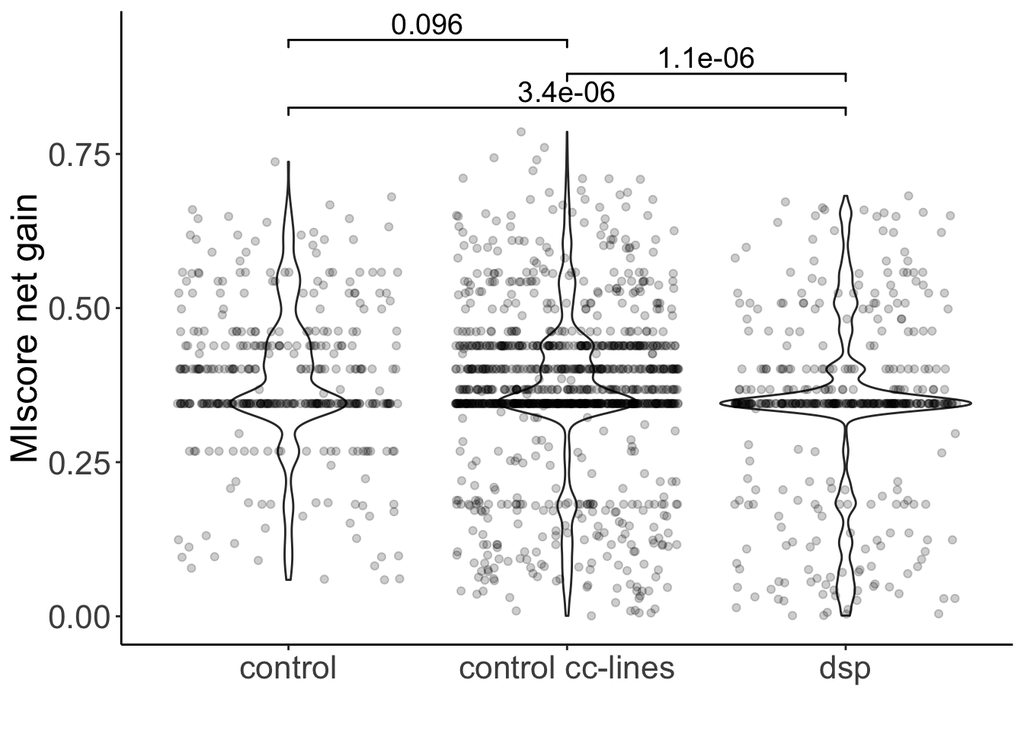

```r
g <- ggplot(comp_pairs_miscore[diff!=0], aes(x=set,y=diff)) +
  geom_violin() +
  geom_jitter(alpha=0.2) +
  ylab('MIscore net gain') +
  xlab('') +
  geom_signif(comparisons = list(c("control","dsp"),
                                 c("control cc-lines","dsp"),
                                 c("control","control cc-lines")),
  # geom_signif(comparisons = c("dsp","control"),
              step_increase=0.07,
              test = wilcox.test.altg,
              tip_length = 0.015,
              textsize = 5) +
  theme(plot.title = element_text(),
        legend.position = "none",
        panel.grid.major = element_blank(),
        panel.grid.minor = element_blank(),
        panel.background = element_blank(),
        axis.line = element_line(),
        axis.text.x = element_text(size=16),
        axis.text.y = element_text(size=16),
        axis.title = element_text(size=18))
g
```

## Correlate interest scores with MIscore progression

If interest score really helps targeting lowly annotated pairs, it should correlate with bigger differences in MIscore progression. This comparison is only possible for DSP-curated papers, of course.

```r
pairs_int_comp <- unique(merge(
  eval_dsp_pairs_formatted,
  comp_pairs_dsp_miscore,
  by.x = "prot_pairs",
  by.y = "pair_id",
  all = F
))

fwrite(
  pairs_int_comp,
  "./processed_data/pairs_int_comp.txt",
  col.names = T,
  row.names = F,
  quote = F,
  sep = "\t"
)
```

### Plots interest scores vs MIscore

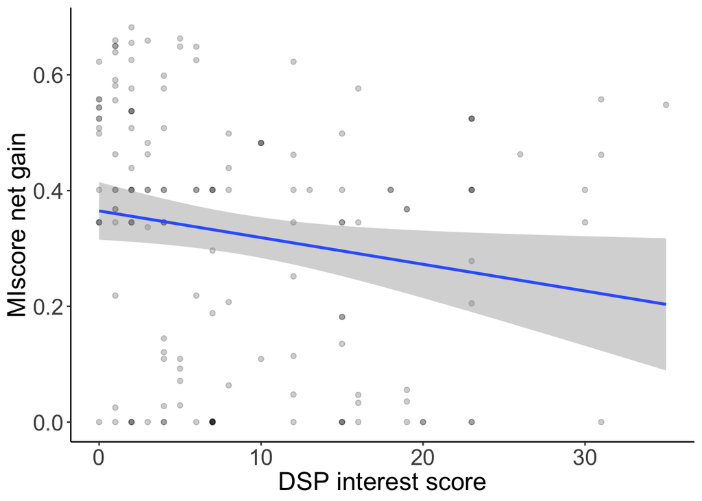

```r
g1 <- ggplot(pairs_int_comp,aes(x=as.numeric(DS.interest.up),y=diff)) +
  geom_point(alpha = 0.2) +
  geom_smooth(method='lm') +
  ylab('MIscore net gain') +
  xlab('DSP interest score') +
  theme(plot.title = element_text(),
        legend.position = "none",
        panel.grid.major = element_blank(),
        panel.grid.minor = element_blank(),
        panel.background = element_blank(),
        axis.line = element_line(),
        axis.text.x = element_text(size=16),
        axis.text.y = element_text(size=16),
        axis.title = element_text(size=18))
g1
```

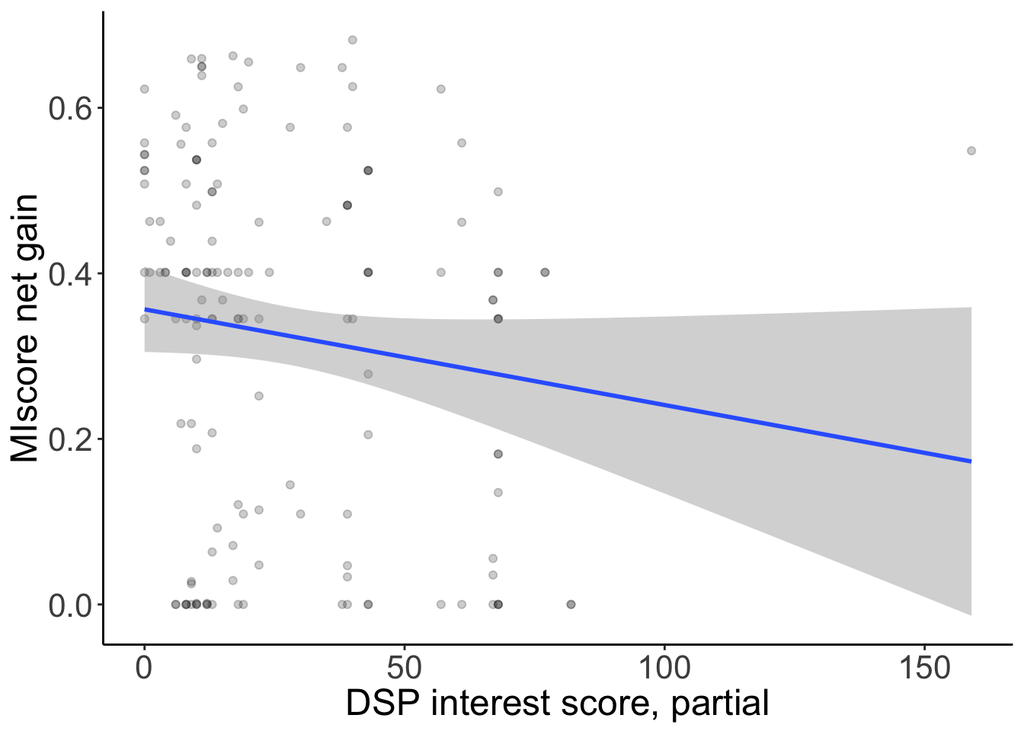

```r
g2 <- ggplot(pairs_int_comp,aes(x=as.numeric(DS.part_interest.up),y=diff)) +
  geom_point(alpha = 0.2) +
  geom_smooth(method='lm') +
  ylab('MIscore net gain') +
  xlab('DSP interest score, partial') +
  theme(plot.title = element_text(),
        legend.position = "none",
        panel.grid.major = element_blank(),
        panel.grid.minor = element_blank(),
        panel.background = element_blank(),
        axis.line = element_line(),
        axis.text.x = element_text(size=16),
        axis.text.y = element_text(size=16),
        axis.title = element_text(size=18))
g2
```

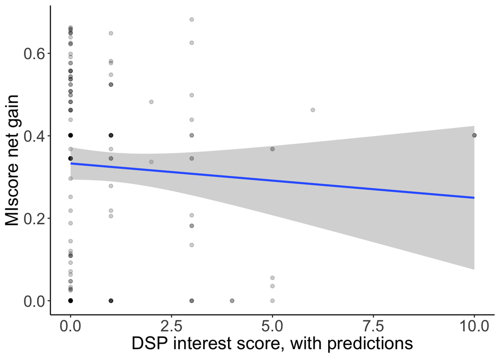

```r
g3 <- ggplot(pairs_int_comp,aes(x=as.numeric(DS.score.pred),y=diff)) +
  geom_point(alpha = 0.2) +
  geom_smooth(method='lm') +
  ylab('MIscore net gain') +
  xlab('DSP interest score, with predictions') +
  theme(plot.title = element_text(),
        legend.position = "none",
        panel.grid.major = element_blank(),
        panel.grid.minor = element_blank(),
        panel.background = element_blank(),
        axis.line = element_line(),
        axis.text.x = element_text(size=16),
        axis.text.y = element_text(size=16),
        axis.title = element_text(size=18))
g3
```

Any version of the interest score is all over the place, with poor correlation with MIscore gains. The correlation seems to be actually negative, if anything.

## Normalization problem evaluation

Let’s check how much of a problem we have with identification of interacting pairs in text mining and predicted datasets.

```r
curated_dsp_sel <-unique(eval_dsp[grepl("yes|Yes",curatable) & pmid %in% publs_curated_dsp$pmid,.(
  pair_id= prot_pairs,
  pmid,
  text_mined = ifelse(
    tm_epmc_pair == "yes" | EVEX_pair == "yes" | STRING_textmining_pair == "yes",
    "yes",
    ifelse(
      tm_epmc_pair == "part" | EVEX_pair == "part" | STRING_textmining_pair == "part",
      "part",
      "no"
    )
  ),
  pw_curated = ifelse(
    reactome_pair == "yes" | OmniPath_interactions_pair == "yes" | OmniPath_ptm_pair == "yes" | STRING_pi_pair == "yes",
    "yes",
    ifelse(
      reactome_pair == "part" | OmniPath_interactions_pair == "part" | OmniPath_ptm_pair == "part" | STRING_pi_pair == "part",
      "part",
      "no"
    )
  ),
  predicted = ifelse(
    iid_pred == "yes",
    "yes",
    ifelse(
       iid_pred == "part",
      "part",
      "no"
    )
  )
  )])

curated_dsp_long <- cSplit(
  curated_dsp_sel,
  splitCols = "pair_id",
  sep = "|",
  direction = "long",
  drop = F
)

intact_pairs_dsp_sel <- intact_human[pmid %in% publs_curated_dsp$pmid,.(
  pmid,
  pair_id,
  imex_curated = "yes"
)]

predicted_vs_curated_dsp_pairs <- unique(merge(
  curated_dsp_long,
  intact_pairs_dsp_sel,
  by = c("pair_id","pmid"),
  all = T
))

predicted_vs_curated_dsp_pairs_annot <- predicted_vs_curated_dsp_pairs[,.(
  pair_id,
  pmid,
  match = ifelse(
    imex_curated == "yes" & is.na(text_mined),
    "not DSP predicted",
    ifelse(
      imex_curated == "yes" & (text_mined == "yes" | pw_curated == "yes" | predicted == "yes"),
      "full match",
      ifelse(
        imex_curated == "yes" & (text_mined == "part" | pw_curated == "part" | predicted == "part"),
        "partial match",
        "false identification"
      )
    )
  ),
  imex_curated,
  text_mined,
  pw_curated,
  predicted
)]

table(predicted_vs_curated_dsp_pairs_annot$match,useNA="ifany")
```

```
##
##        full match not DSP predicted     partial match              <NA>
##                37               300                85              2317
```

```r
true_positives_overview <- melt(
  predicted_vs_curated_dsp_pairs_annot[match=="full match"],
  id.vars = c("pmid","pair_id"),
  measure.vars = c("text_mined","pw_curated","predicted"))

table(true_positives_overview$variable,
      true_positives_overview$value,
      useNA = "ifany")
```

```
##
##              no part yes
##   text_mined  0    0  37
##   pw_curated 14   21   2
##   predicted   8   27   2
```

```r
part_positives_overview <- melt(
  predicted_vs_curated_dsp_pairs_annot[match=="partial match"],
  id.vars = c("pmid","pair_id"),
  measure.vars = c("text_mined","pw_curated","predicted"))

table(part_positives_overview$variable,
      part_positives_overview$value,
      useNA = "ifany")
```

```
##
##              no part
##   text_mined  0   85
##   pw_curated 32   53
##   predicted   6   79
```

```r
false_positives_overview <- melt(
  predicted_vs_curated_dsp_pairs_annot[is.na(match)],
  id.vars = c("pmid","pair_id"),
  measure.vars = c("text_mined","pw_curated","predicted"))

table(false_positives_overview$variable,
      false_positives_overview$value,
      useNA = "ifany")
```

```
##
##                no part  yes
##   text_mined    0 1960  357
##   pw_curated  653 1659    5
##   predicted   125 2190    2
```

```r
table(predicted_vs_curated_dsp_pairs_annot$text_mined,useNA = "ifany")
```

```
##
## part  yes <NA>
## 2045  394  300
```

```r
table(predicted_vs_curated_dsp_pairs_annot$pw_curated,useNA = "ifany")
```

```
##
##   no part  yes <NA>
##  699 1733    7  300
```

```r
table(predicted_vs_curated_dsp_pairs_annot$predicted,useNA = "ifany")
```

```
##
##   no part  yes <NA>
##  139 2296    4  300
```

### Manual evaluation specific pairs

```r
pairs_int_comp_long <- cSplit(
  pairs_int_comp,
  "pmids",
  sep = "|",
  drop = F,
  direction = "long"
)

pairs_int_comp_long <- pairs_int_comp_long[,pmid:=as.character(pmids)]

pairs_int_comp_prepairs <- unique(merge(
  pairs_int_comp_long,
  curated_dsp_long[,.(
    pmid,
    pred_prot_pairs=pair_id,
    pred_p1 = gsub("_.*","",pair_id),
    pred_p2 = gsub(".*_","",pair_id))],
  allow.cartesian = T,
  by = "pmid",
  all.x = T,
  all.y = F
))

prots <- unique(rbind(
  unique(pairs_int_comp_prepairs[,.(p = p1)]),
  unique(pairs_int_comp_prepairs[,.(p = p2)]),
  unique(pairs_int_comp_prepairs[,.(p = pred_p1)]),
  unique(pairs_int_comp_prepairs[,.(p = pred_p2)])
))

# fwrite(
#   prots,
#   "./processed_data/prots.txt",
#   col.names = F,
#   row.names = F,
#   sep = "\t",
#   quote = F
# )
## I checked and every protein in the list is human, so I can use the UniProt.ws package to get some more info about them (gene names).

prot_list <- prots$p
up <- UniProt.ws(taxId=9606)

prots_genenames <- select(
        up,
        keys = prot_list,
        columns = c("GENES","ENTRY-NAME")
)
```

```
## Getting extra data for P06241, P07947, P03372... (400 total)
```

```
## Getting extra data for O00139, O15066, P62826... (392 total)
```

```r
pairs_man_eval_pt1 <- unique(merge(
  pairs_int_comp_prepairs,
  prots_genenames,
  by.x = "p1",
  by.y = "UNIPROTKB",
  all.x = T,
  all.y = F
))

pairs_man_eval_pt2 <- unique(merge(
  pairs_man_eval_pt1,
  prots_genenames,
  by.x = "p2",
  by.y = "UNIPROTKB",
  all.x = T,
  all.y = F
))

pairs_man_eval_pt3 <- unique(merge(
  pairs_man_eval_pt2,
  prots_genenames,
  by.x = "pred_p1",
  by.y = "UNIPROTKB",
  all.x = T,
  all.y = F
))

colnames(pairs_man_eval_pt3) <- c("pred_p1","p2","p1","pmid","prot_pairs","pmids","DS.interest.up","DS.part_interest.up","DS.score.pred","miscore_before","miscore_after","diff","set","pred_prot_pairs","pred_p2","p1_genenames","p1_upid","p2_genenames","p2_upid","pred_p1_genenames","pred_p1_upid")

pairs_man_eval_pt4 <- unique(merge(
  pairs_man_eval_pt3,
  prots_genenames,
  by.x = "pred_p2",
  by.y = "UNIPROTKB",
  all.x = T,
  all.y = F
))

pairs_man_eval <- pairs_man_eval_pt4[,.(
  pmid,
  DS.interest.up,
  DS.part_interest.up,
  DS.score.pred,
  miscore_before,
  miscore_after,
  diff,
  set,
  prot_pairs,
  pred_prot_pairs,
  p1,
  p1_genenames,
  p1_upid,
  pred_p1,
  pred_p1_genenames,
  pred_p1_upid,
  p2,
  p2_genenames,
  p2_upid,
  pred_p2,
  pred_p2_genenames = GENES,
  pred_p2_upid = `ENTRY-NAME`
)]

prot_preds <- unique(rbind(
  unique(pairs_man_eval[,.(p = p1,pred_p=pred_p1,p_gs=p1_genenames,pred_p_gs=pred_p1_genenames)]),
  unique(pairs_man_eval[,.(p = p2,pred_p=pred_p2,p_gs=p2_genenames,pred_p_gs=pred_p2_genenames)])
))

prot_preds_qual <- unique(prot_preds[,.(
  p,
  pred_p,
  wrong_pred_p = ifelse(
    is.na(pred_p),
    "no map",
    ifelse(
      p != pred_p,
      "1",
      "0"
    )
  ),
  p_gs,
  pred_p_gs
)])

fwrite(
  prot_preds_qual,
  "./processed_data/prot_preds_qual.txt",
  col.names = T,
  row.names = F,
  quote = F,
  sep = "\t"
)
```

I evaluate individually each of the text-mined id predictions, grouping the wrong predictions in two categories: those cases where I could find exact synonyms for the gene symbol for the real id and the predicted one in UniProt and those where a close synonym was found. Close synonyms are cases of gene names sharing the same root (first few letters), but different suffix (ordinarily, subunit number, in some cases there is an additional letter). I account these two categories in different columns.

```r
prot_preds_qual_manual <- data.table(read_excel(
  "./processed_data/prot_preds_qual_manual.xlsx",
  sheet = 1,
  col_names = T,
  col_types = "text"
),
check.names = T)

pairs_man_eval_diagn_pt1 <- unique(merge(
  pairs_man_eval,
  prot_preds_qual_manual,
  by.x = c("p1","p1_genenames","pred_p1","pred_p1_genenames"),
  by.y = c("p","p_gs","pred_p","pred_p_gs"),
  all.x = T,
  all.y = F
))

pairs_man_eval_diagn_pt2 <- unique(merge(
  pairs_man_eval_diagn_pt1,
  prot_preds_qual_manual,
  by.x = c("p2","p2_genenames","pred_p2","pred_p2_genenames"),
  by.y = c("p","p_gs","pred_p","pred_p_gs"),
  all.x = T,
  all.y = F
))

pairs_man_eval_diagn_pt3 <- unique(pairs_man_eval_diagn_pt2[,.(
  pmid,
  DS.interest.up,
  DS.part_interest.up,
  DS.score.pred,
  miscore_before,
  miscore_after,
  diff,
  prot_pairs,
  pred_prot_pairs,
  wrong_pred_p1 = ifelse(
    is.na(wrong_pred_p.x),
    NA,
    as.numeric(wrong_pred_p.x)
  ),
  pred_syn_p1 = ifelse(
    is.na(wrong_pred_p.x),
    NA,
    ifelse(
      is.na(pred_synonym.x) | pred_synonym.x == "",
      0,
      as.numeric(pred_synonym.x)
    )
  ),
  pred_close_syn_p1 = ifelse(
    is.na(wrong_pred_p.x),
    NA,
    ifelse(
      is.na(pred_close_syn.x) | pred_close_syn.x == "",
      0,
      as.numeric(pred_close_syn.x)
    )
  ),
  wrong_pred_p2 = ifelse(
    is.na(wrong_pred_p.y),
    NA,
    as.numeric(wrong_pred_p.y)
  ),
  pred_syn_p2 = ifelse(
    is.na(wrong_pred_p.y),
    NA,
    ifelse(
      is.na(pred_synonym.y) | pred_synonym.y == "",
      0,
      as.numeric(pred_synonym.y)
    )
  ),
  pred_close_syn_p2 = ifelse(
    is.na(wrong_pred_p.y),
    NA,
    ifelse(
      is.na(pred_close_syn.y) | pred_close_syn.y == "",
      0,
      as.numeric(pred_close_syn.y)
    )
  )
)])
pairs_man_eval_diagn <- data.table(mutate(
  pairs_man_eval_diagn_pt3[!is.na(wrong_pred_p1) & !is.na(wrong_pred_p2)],
  wrong_score = wrong_pred_p1 + wrong_pred_p2,
  syn_score = pred_syn_p1 + pred_syn_p2,
  close_syn_score = pred_close_syn_p1 + pred_close_syn_p2,
  full_syn_score = pred_syn_p1 + pred_syn_p2 + pred_close_syn_p1 + pred_close_syn_p2))

table(pairs_man_eval_diagn$wrong_score,useNA="ifany")
```

```
##
##    0    1    2
##  172 1498 6231
```

```r
table(pairs_man_eval_diagn$syn_score,useNA="ifany")
```

```
##
##    0    1    2
## 7136  742   23
```

```r
table(pairs_man_eval_diagn$close_syn_score,useNA="ifany")
```

```
##
##    0    1    2
## 7057  803   41
```

```r
table(pairs_man_eval_diagn$full_syn_score,useNA="ifany")
```

```
##
##    0    1    2
## 6325 1479   97
```

```r
pair_normalization_man_eval <- unique(pairs_man_eval_diagn[,.(
  pred_prot_pairs = paste(unique(pred_prot_pairs),collapse="|"),
  DS.interest.up,
  DS.part_interest.up,
  DS.score.pred,
  diff,
  wrong_score_total = sum(wrong_score),
  syn_score_total = sum(syn_score),
  close_syn_score_total = sum(close_syn_score),
  full_syn_score_total = sum(full_syn_score)
), by = c("prot_pairs","pmid")])
```

#### Plots normalization problem evaluation

##### Wrong ids vs interest scores

First I check whether the different versions of the interest score correlate with a large number of misidentified pairs.

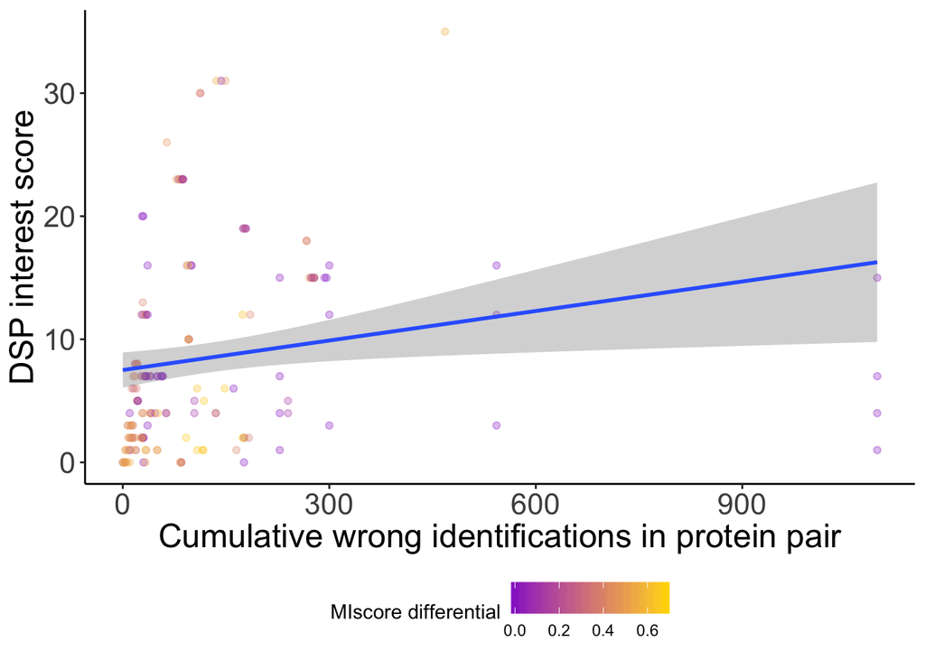

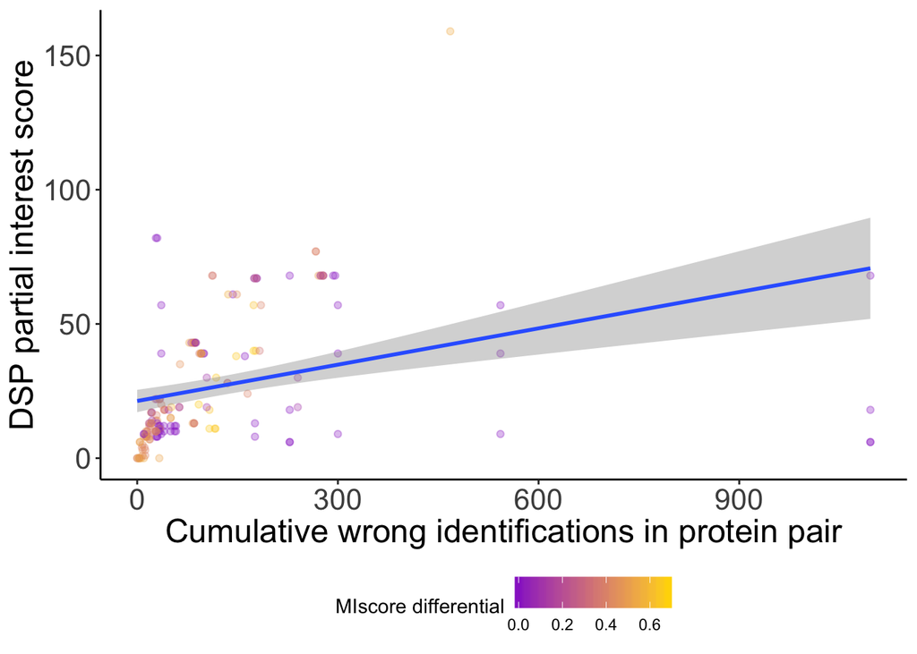

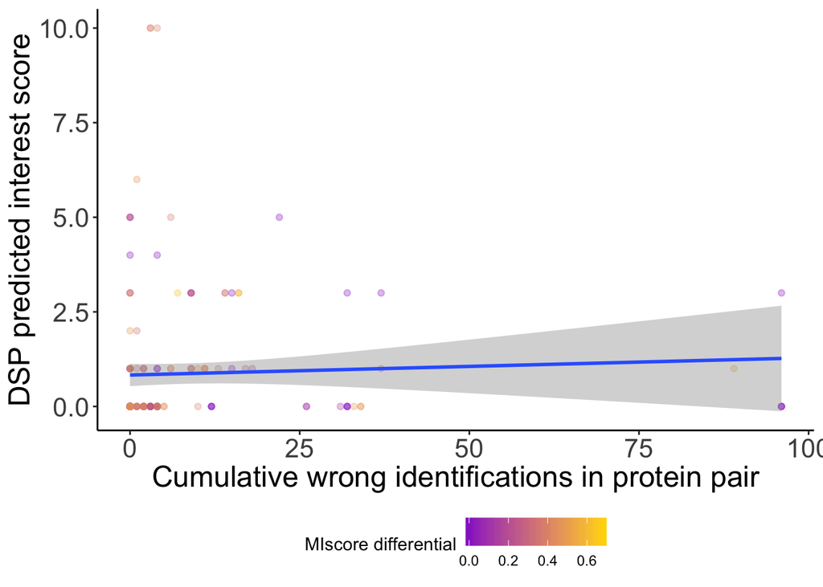

```r
pair_normalization_man_eval_syn <- data.table(mutate(
  pair_normalization_man_eval,
  syn_influence = ifelse(
    full_syn_score_total == 0,
    "no synonyms",
    ifelse(
      full_syn_score_total != 0 & full_syn_score_total <= 10,
      "mild synonyms content",
      "strong synonyms content"
    )
  ),
  exact_syn_influence = ifelse(
    syn_score_total == 0,
    "no exact synonyms",
    ifelse(
      syn_score_total != 0 & syn_score_total <= 10,
      "mild exact synonyms content",
      "strong exact synonyms content"
    )
  ),
  close_syn_influence = ifelse(
    close_syn_score_total == 0,
    "no close synonyms",
    ifelse(
      close_syn_score_total != 0 & close_syn_score_total <= 10,
      "mild close synonyms content",
      "strong close synonyms content"
    )
  )
))

pair_normalization_man_eval_syn <- data.table(mutate(
  pair_normalization_man_eval_syn,
  syn_influence = factor(syn_influence,levels = c("no synonyms","mild synonyms content","strong synonyms content")),
  close_syn_influence = factor(close_syn_influence,levels = c("no close synonyms","mild close synonyms content","strong close synonyms content")),
  exact_syn_influence = factor(exact_syn_influence,levels = c("no exact synonyms","mild exact synonyms content","strong exact synonyms content"))
))
```

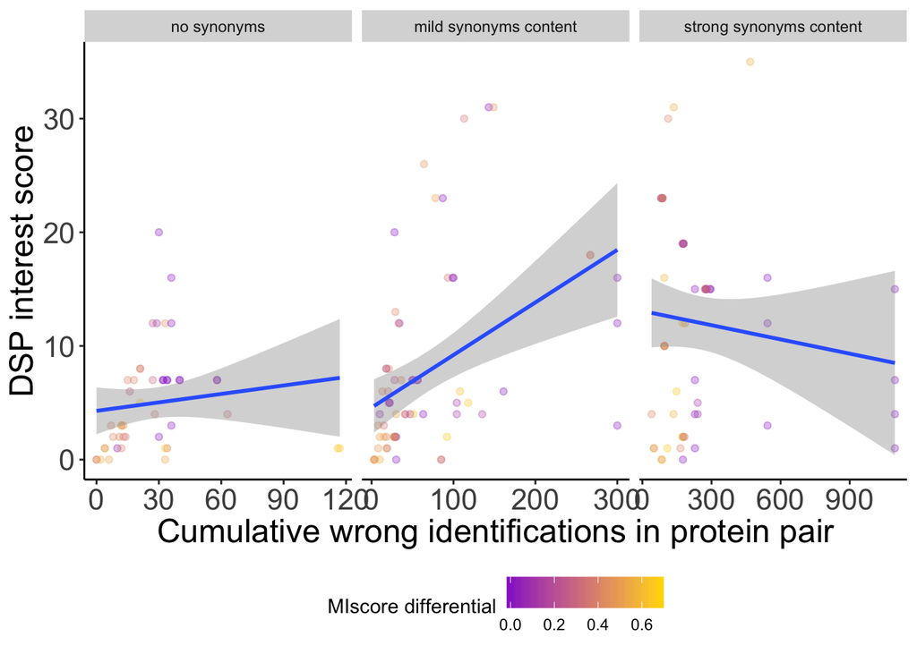

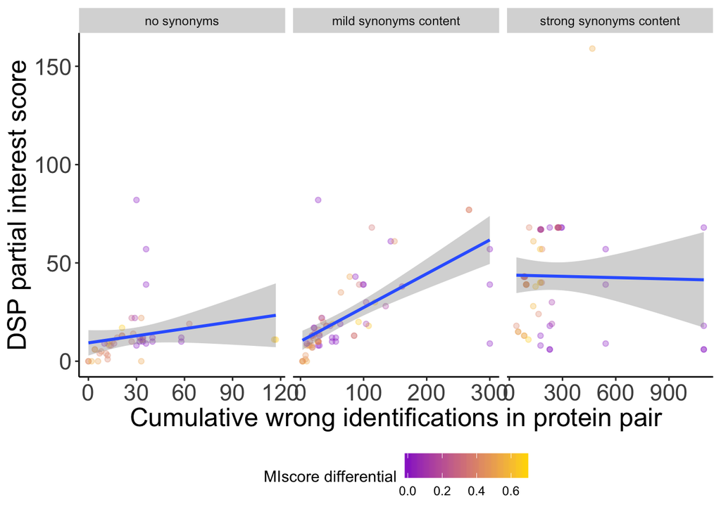

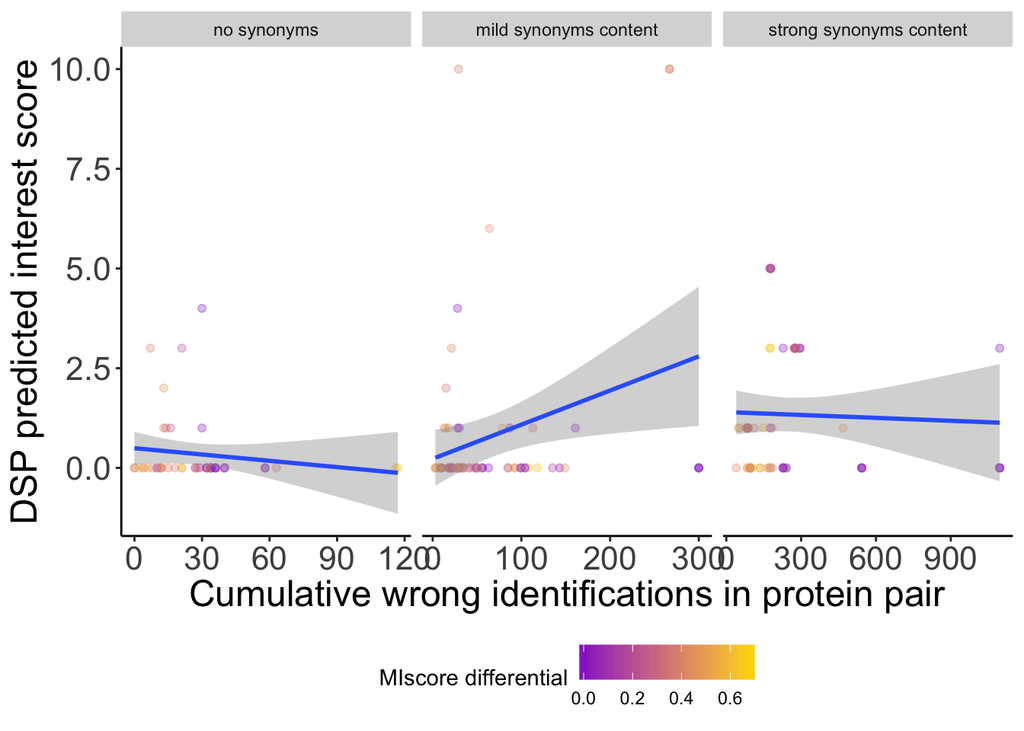

##### Wrong ids vs miscore

I plot the differential in MIscore obtained during the DSP project duration versus the wrong identification score I have calculated. Colour is now mapped to the different interest scores.

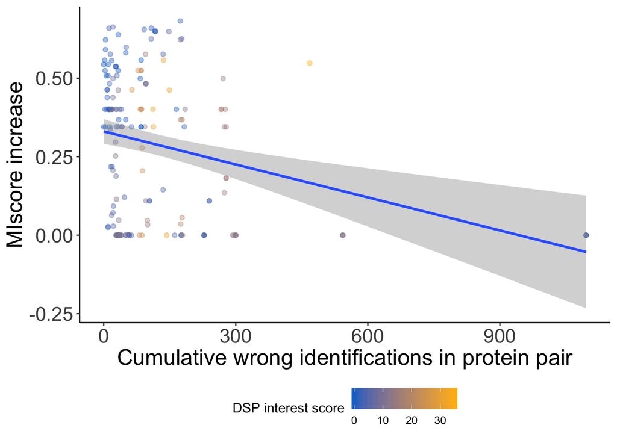

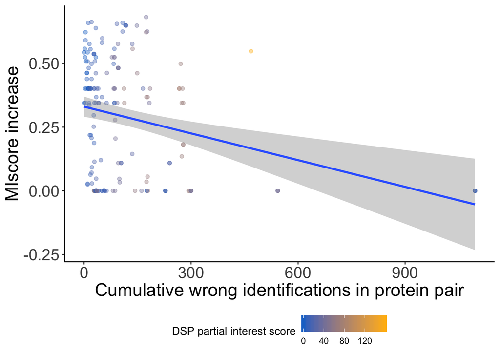

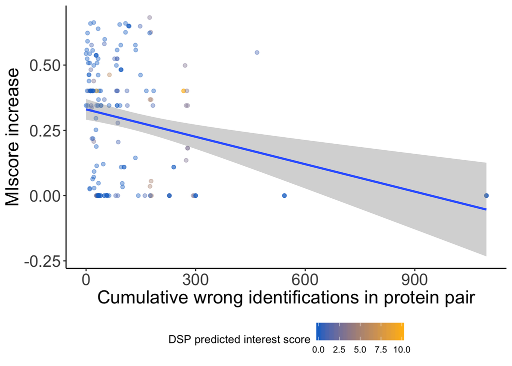

It seems low increments in MIscore roughly correlate with number of wrongly identified pairs.

## Evaluation of mutation data

This is for an unrelated issue: how many curated DSP publications ended up containing mutation data?

```r
dsp_muts_ints <- intact_dsp[grepl("mutation",Feature.s..interactor.A) | grepl("mutation",Feature.s..interactor.B)]
dsp_muts_publs <- unique(dsp_muts_ints[,.(Publication.Identifier.s.)])
```

There are 116 binaries with reported mutations curated, in 20 publications.

## Evaluation of relevance score historic impact

I check the accuracy of the relevance score since it was introduced.

```r
evaluated_old <- fread(
  "./source_data/pmids_pre_relevance.txt",
  check.names = T,
  header = T,
  sep = "\t",
  colClasses = "character",
  stringsAsFactors = F
)

evaluated_old_simple <- unique(evaluated_old[,.(
  pmid = PMID,
  eval_old = "yes"
)])

eval_dsp_pmids_rel <- unique(eval_dsp[curatable!="",.(
  pmid,
  curatable,
  relevance.up,
  relevance
)])

eval_dsp_rel_check <- unique(merge(
  eval_dsp_pmids_rel,
  evaluated_old_simple,
  by = "pmid",
  all = T
))

eval_dsp_rel_new <- eval_dsp_rel_check[is.na(eval_old),.(
  pmid,
  curatable,
  curatable_simple = ifelse(
    grepl("yes|Yes",curatable),
    "yes",
    "no"
  ),
  relevance = as.numeric(gsub(',','.',relevance)),
  relevance.up = as.numeric(relevance.up)
)]
table(eval_dsp_rel_new$curatable_simple,useNA="ifany")
```

```
##
##  no yes
##  43  85
```

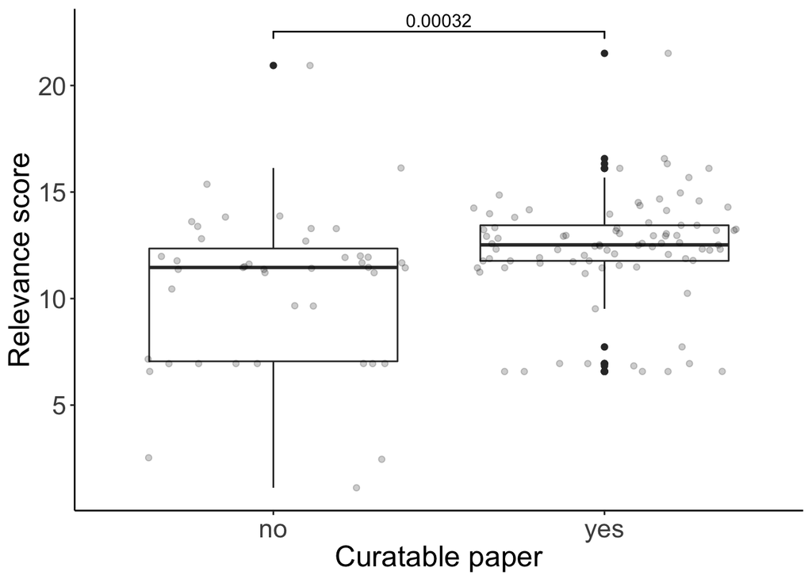

```r
g16 <- ggplot(eval_dsp_rel_new, aes(x=curatable_simple,y=relevance)) +
  geom_boxplot() +
  geom_jitter(alpha=0.2) +
  ylab('Relevance score') +
  xlab('Curatable paper') +
  geom_signif(comparisons = list(c("yes","no")),
              step_increase=0.07,
              test = wilcox.test.altg,
              tip_length = 0.015,
              textsize = 4) +
  theme(plot.title = element_text(),
        legend.position = "none",
        panel.grid.major = element_blank(),
        panel.grid.minor = element_blank(),
        panel.background = element_blank(),
        axis.line = element_line(),
        axis.text.x = element_text(size=16),
        axis.text.y = element_text(size=16),
        axis.title = element_text(size=18))
g16
```